# Predspot end to end: crime hotspots for Natal, Brazil

This notebook walks through the whole Predspot workflow on the city of Natal (Rio Grande do Norte, Brazil), using **synthetic** crime events so that it runs anywhere without confidential police data:

1. fetch the city boundary from OpenStreetMap;
2. generate synthetic crime events with spatial hotspots and temporal patterns;
3. build the `Dataset`, the spatial grids and the spatio-temporal series (KDE and counts);
4. extract time series features;
5. fit, evaluate and inspect a `PredictionPipeline`;
6. forecast the next months and check how well the true hotspots are recovered.

Every intermediate object is displayed so you can see exactly what flows between the steps. Requirements: `pip install "predspot[osm]" matplotlib`.

```python
import warnings

import geopandas as gpd
import matplotlib.pyplot as plt
import numpy as np
import pandas as pd

import predspot
from predspot import Dataset, PredictionPipeline, PandasFeatureUnion, generate_crimes, get_city_shape
from predspot.crime_mapping import KDE, QuadratCount, create_gridhexagonal, create_gridpoints
from predspot.feature_engineering import AR, Diff, Seasonality, Trend

warnings.filterwarnings("ignore", category=UserWarning)
pd.set_option("display.width", 120)
pd.set_option("display.max_columns", 20)
plt.rcParams["figure.dpi"] = 100

print("predspot", predspot.__version__, "| geopandas", gpd.__version__, "| pandas", pd.__version__)
```

import warnings import geopandas as gpd import matplotlib.pyplot as plt import numpy as np import pandas as pd import predspot from predspot import Dataset, PredictionPipeline, PandasFeatureUnion, generate_crimes, get_city_shape from predspot.crime_mapping import KDE, QuadratCount, create_gridhexagonal, create_gridpoints from predspot.feature_engineering import AR, Diff, Seasonality, Trend warnings.filterwarnings("ignore", category=UserWarning) pd.set_option("display.width", 120) pd.set_option("display.max_columns", 20) plt.rcParams["figure.dpi"] = 100 print("predspot", predspot.__version__, "| geopandas", gpd.__version__, "| pandas", pd.__version__)

```
predspot 0.2.0 | geopandas 1.1.4 | pandas 3.0.3
```

## 1. Study area: the boundary of Natal

`get_city_shape` geocodes a place name with [osmnx](https://osmnx.readthedocs.io) (Nominatim) and returns its boundary as a GeoDataFrame in WGS84. The query should be specific enough for the first match to be the municipality.

```python
city = get_city_shape("Natal, RN, Brazil")
city
```

city = get_city_shape("Natal, RN, Brazil") city

|  | geometry | bbox_west | bbox_south | bbox_east | bbox_north | place_id | osm_type | osm_id | lat | lon | class | type | place_rank | importance | addresstype | name | display_name |
| --- | --- | --- | --- | --- | --- | --- | --- | --- | --- | --- | --- | --- | --- | --- | --- | --- | --- |
| 0 | POLYGON ((-35.29124 -5.73221, -35.29121 -5.732... | -35.291237 | -5.900211 | -35.153103 | -5.702738 | 14119496 | relation | 301091 | -5.805398 | -35.20809 | boundary | administrative | 16 | 0.583903 | municipality | Natal | Natal, Rio Grande do Norte, Northeast Region, ... |

```python
polygon = city.geometry.iloc[0]
print("geometry:", polygon.geom_type, "| vertices:", len(polygon.exterior.coords))
print("bounds (W, S, E, N):", np.round(city.total_bounds, 4))
area_km2 = city.to_crs(city.estimate_utm_crs()).area.iloc[0] / 1e6
print(f"area: {area_km2:.1f} km²")

ax = city.plot(figsize=(5, 6), color="#f2f2f2", edgecolor="black")
ax.set_title("Natal, RN (OpenStreetMap boundary)")
ax.set_axis_off()
```

polygon = city.geometry.iloc[0] print("geometry:", polygon.geom_type, "| vertices:", len(polygon.exterior.coords)) print("bounds (W, S, E, N):", np.round(city.total_bounds, 4)) area_km2 = city.to_crs(city.estimate_utm_crs()).area.iloc[0] / 1e6 print(f"area: {area_km2:.1f} km²") ax = city.plot(figsize=(5, 6), color="#f2f2f2", edgecolor="black") ax.set_title("Natal, RN (OpenStreetMap boundary)") ax.set_axis_off()

```
geometry: Polygon | vertices: 786
bounds (W, S, E, N): [-35.2912  -5.9002 -35.1531  -5.7027]
area: 166.7 km²
```

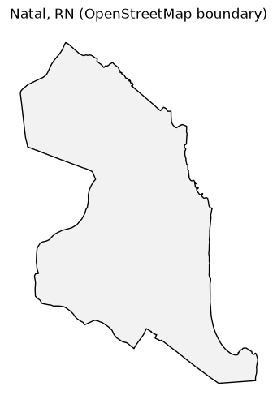

## 2. Synthetic crime events

`generate_crimes` draws events from a space-time point process inside the polygon: a mixture of Gaussian **hotspots** plus a uniform background in space, and a temporal intensity with a linear **trend**, an **annual** cycle and **day-of-week** / **hour-of-day** profiles. With `return_hotspots=True` we also get the hotspot centres, which lets us check later whether the model finds them.

```python
crimes, hotspots = generate_crimes(
    city,
    n_events=12_000,
    start="2019-01-01",
    end="2021-12-31",
    n_hotspots=5,
    hotspot_share=0.65,
    hotspot_sd_km=0.7,
    trend=0.4,               # +40% events from start to end
    annual_amplitude=0.25,   # busier around the peak month...
    annual_peak_month=12,    # ...December
    seed=2019,
    return_hotspots=True,
)
crimes.head(10)
```

crimes, hotspots = generate_crimes( city, n_events=12_000, start="2019-01-01", end="2021-12-31", n_hotspots=5, hotspot_share=0.65, hotspot_sd_km=0.7, trend=0.4, # +40% events from start to end annual_amplitude=0.25, # busier around the peak month... annual_peak_month=12, # ...December seed=2019, return_hotspots=True, ) crimes.head(10)

|  | tag | t | lon | lat |
| --- | --- | --- | --- | --- |
| 0 | robbery | 2019-01-01 08:07:29 | -35.262821 | -5.826621 |
| 1 | burglary | 2019-01-01 11:04:33 | -35.184192 | -5.839420 |
| 2 | assault | 2019-01-01 15:45:04 | -35.263080 | -5.833051 |
| 3 | robbery | 2019-01-01 19:57:59 | -35.264664 | -5.837595 |
| 4 | burglary | 2019-01-01 20:23:07 | -35.256722 | -5.819229 |
| 5 | burglary | 2019-01-01 22:25:05 | -35.262523 | -5.825538 |
| 6 | burglary | 2019-01-01 23:33:14 | -35.256481 | -5.821109 |
| 7 | burglary | 2019-01-02 00:35:11 | -35.192001 | -5.805592 |
| 8 | homicide | 2019-01-02 09:55:04 | -35.253808 | -5.732047 |
| 9 | homicide | 2019-01-02 11:06:07 | -35.206620 | -5.760610 |

```python
print(crimes.shape)
crimes.describe(include="all").T
```

print(crimes.shape) crimes.describe(include="all").T

```
(12000, 4)
```

|  | count | unique | top | freq | mean | min | 25% | 50% | 75% | max | std |
| --- | --- | --- | --- | --- | --- | --- | --- | --- | --- | --- | --- |
| tag | 12000 | 4 | burglary | 5397 | NaN | NaN | NaN | NaN | NaN | NaN | NaN |
| t | 12000 | NaN | NaN | NaN | 2020-08-04 09:23:35.348416768 | 2019-01-01 08:07:29 | 2019-11-18 00:35:28.500000 | 2020-09-02 18:24:44 | 2021-04-22 17:33:00.249999872 | 2021-12-30 22:51:11 | NaN |
| lon | 12000.0 | NaN | NaN | NaN | -35.23946 | -35.290021 | -35.263962 | -35.252215 | -35.222052 | -35.153427 | 0.030905 |
| lat | 12000.0 | NaN | NaN | NaN | -5.822253 | -5.899403 | -5.841009 | -5.826307 | -5.807527 | -5.704011 | 0.039883 |

```python
hotspots
```

hotspots

|  | sd_km | share | geometry |
| --- | --- | --- | --- |
| 0 | 0.7 | 0.312219 | POINT (-35.26454 -5.82894) |
| 1 | 0.7 | 0.094299 | POINT (-35.18172 -5.8832) |
| 2 | 0.7 | 0.051078 | POINT (-35.22805 -5.866) |
| 3 | 0.7 | 0.114319 | POINT (-35.26133 -5.81869) |
| 4 | 0.7 | 0.078085 | POINT (-35.23374 -5.77675) |

```python
crimes["tag"].value_counts().to_frame("events").assign(share=lambda d: (d["events"] / len(crimes)).round(3))
```

crimes["tag"].value_counts().to_frame("events").assign(share=lambda d: (d["events"] / len(crimes)).round(3))

| tag | events | share |
| --- | --- | --- |
| burglary | 5397 | 0.450 |
| robbery | 3564 | 0.297 |
| assault | 2399 | 0.200 |
| homicide | 640 | 0.053 |

### 2.1 Where and when do the events happen?

```python
fig, ax = plt.subplots(figsize=(7, 8))
city.plot(ax=ax, color="#f7f7f7", edgecolor="black")
sample = crimes.sample(4000, random_state=0)
ax.scatter(sample["lon"], sample["lat"], s=3, alpha=0.35, color="#1f4e79", label="events (sample)")
hotspots.plot(ax=ax, color="#d62728", marker="*", markersize=150, zorder=5, label="hotspot centres")
ax.legend(loc="lower left")
ax.set_title("Synthetic crime events in Natal")
ax.set_axis_off()
```

fig, ax = plt.subplots(figsize=(7, 8)) city.plot(ax=ax, color="#f7f7f7", edgecolor="black") sample = crimes.sample(4000, random_state=0) ax.scatter(sample["lon"], sample["lat"], s=3, alpha=0.35, color="#1f4e79", label="events (sample)") hotspots.plot(ax=ax, color="#d62728", marker="*", markersize=150, zorder=5, label="hotspot centres") ax.legend(loc="lower left") ax.set_title("Synthetic crime events in Natal") ax.set_axis_off()

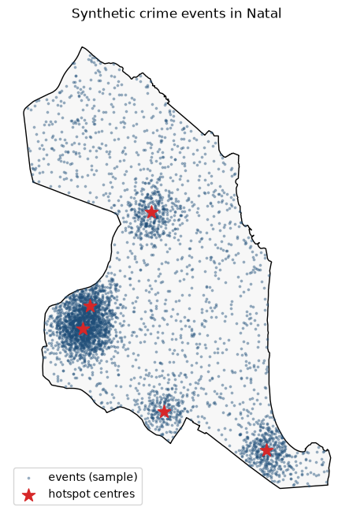

```python
monthly = crimes.set_index("t").resample("ME").size().rename("events")
fig, axes = plt.subplots(1, 3, figsize=(15, 3.6))
monthly.plot(ax=axes[0], marker="o")
axes[0].set_title("Events per month (trend + annual cycle)")
axes[0].set_xlabel("")
crimes["t"].dt.day_name().value_counts().reindex(
    ["Monday", "Tuesday", "Wednesday", "Thursday", "Friday", "Saturday", "Sunday"]
).plot.bar(ax=axes[1], color="#1f4e79")
axes[1].set_title("Events per weekday")
crimes["t"].dt.hour.value_counts().sort_index().plot.bar(ax=axes[2], color="#1f4e79", width=0.9)
axes[2].set_title("Events per hour of day")
fig.tight_layout()
```

monthly = crimes.set_index("t").resample("ME").size().rename("events") fig, axes = plt.subplots(1, 3, figsize=(15, 3.6)) monthly.plot(ax=axes[0], marker="o") axes[0].set_title("Events per month (trend + annual cycle)") axes[0].set_xlabel("") crimes["t"].dt.day_name().value_counts().reindex( ["Monday", "Tuesday", "Wednesday", "Thursday", "Friday", "Saturday", "Sunday"] ).plot.bar(ax=axes[1], color="#1f4e79") axes[1].set_title("Events per weekday") crimes["t"].dt.hour.value_counts().sort_index().plot.bar(ax=axes[2], color="#1f4e79", width=0.9) axes[2].set_title("Events per hour of day") fig.tight_layout()

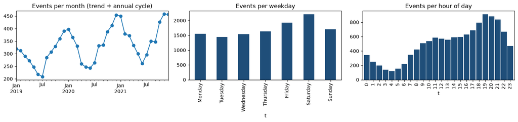

## 3. Dataset, grids and the spatio-temporal series

`Dataset` validates the events (columns `tag`, `t`, `lon`, `lat`) and turns them into a GeoDataFrame of points in WGS84, together with the study area.

```python
dataset = Dataset(crimes, city)
dataset
```

dataset = Dataset(crimes, city) dataset

```
predspot.Dataset<
  crimes = GeoDataFrame(12000),
    >> {'burglary': 5397, 'robbery': 3564, 'assault': 2399, 'homicide': 640}
  study_area = GeoDataFrame(1),
>
```

```python
dataset.crimes.head()
```

dataset.crimes.head()

|  | tag | t | lon | lat | geometry |
| --- | --- | --- | --- | --- | --- |
| 0 | robbery | 2019-01-01 08:07:29 | -35.262821 | -5.826621 | POINT (-35.26282 -5.82662) |
| 1 | burglary | 2019-01-01 11:04:33 | -35.184192 | -5.839420 | POINT (-35.18419 -5.83942) |
| 2 | assault | 2019-01-01 15:45:04 | -35.263080 | -5.833051 | POINT (-35.26308 -5.83305) |
| 3 | robbery | 2019-01-01 19:57:59 | -35.264664 | -5.837595 | POINT (-35.26466 -5.8376) |
| 4 | burglary | 2019-01-01 20:23:07 | -35.256722 | -5.819229 | POINT (-35.25672 -5.81923) |

### 3.1 Grids

Predspot discretises the city into **places**. Two kinds of grid are built below: a grid of **points** every 500 m (used by `KDE`) and a grid of **hexagons** of 1 km² (used by `QuadratCount`). Only cells intersecting the city are kept; each grid has `lon`/`lat` columns with the cell centroid and an index named `places`.

```python
points = create_gridpoints(city, resolution=0.5)
hexes = create_gridhexagonal(city, resolution=1.0)
print(f"{len(points)} grid points at 500 m | {len(hexes)} hexagons of 1 km²")
points.head()
```

points = create_gridpoints(city, resolution=0.5) hexes = create_gridhexagonal(city, resolution=1.0) print(f"{len(points)} grid points at 500 m | {len(hexes)} hexagons of 1 km²") points.head()

```
638 grid points at 500 m | 207 hexagons of 1 km²
```

| places | lon | lat | geometry |
| --- | --- | --- | --- |
| 55 | -35.180730 | -5.895619 | POINT (-35.18073 -5.89562) |
| 56 | -35.176126 | -5.895619 | POINT (-35.17613 -5.89562) |
| 57 | -35.171521 | -5.895619 | POINT (-35.17152 -5.89562) |
| 58 | -35.166917 | -5.895619 | POINT (-35.16692 -5.89562) |
| 59 | -35.162312 | -5.895619 | POINT (-35.16231 -5.89562) |

```python
fig, axes = plt.subplots(1, 2, figsize=(12, 7))
city.boundary.plot(ax=axes[0], color="black")
points.plot(ax=axes[0], markersize=4, color="#1f4e79")
axes[0].set_title(f"Point grid, 500 m ({len(points)} places)")
city.boundary.plot(ax=axes[1], color="black")
hexes.plot(ax=axes[1], facecolor="none", edgecolor="#1f4e79", linewidth=0.6)
axes[1].set_title(f"Hexagonal grid, 1 km² ({len(hexes)} places)")
for ax in axes:
    ax.set_axis_off()
```

fig, axes = plt.subplots(1, 2, figsize=(12, 7)) city.boundary.plot(ax=axes[0], color="black") points.plot(ax=axes[0], markersize=4, color="#1f4e79") axes[0].set_title(f"Point grid, 500 m ({len(points)} places)") city.boundary.plot(ax=axes[1], color="black") hexes.plot(ax=axes[1], facecolor="none", edgecolor="#1f4e79", linewidth=0.6) axes[1].set_title(f"Hexagonal grid, 1 km² ({len(hexes)} places)") for ax in axes: ax.set_axis_off()

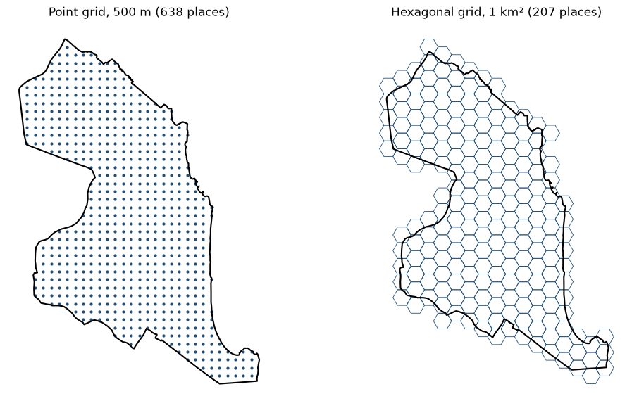

### 3.2 Spatio-temporal mapping

A mapping assigns one value to every `(period, place)` pair. `KDE` fits a Gaussian kernel density estimate to the events of each period and evaluates it at the grid points; `QuadratCount` counts the events inside each polygon. Both return the same object: a `pandas.Series` named `crime_density` with a `(t, places)` MultiIndex — the **spatio-temporal series**.

```python
kde = KDE(tfreq="M", grid=points, bandwidth="silverman")
stseries = kde.fit_transform(dataset.crimes)
print(type(stseries).__name__, stseries.shape, "| KDE factor:", round(kde.factor, 4))
stseries.head(8)
```

kde = KDE(tfreq="M", grid=points, bandwidth="silverman") stseries = kde.fit_transform(dataset.crimes) print(type(stseries).__name__, stseries.shape, "| KDE factor:", round(kde.factor, 4)) stseries.head(8)

```
Series (22968,) | KDE factor: 0.3824
```

```
t           places
2019-01-31  55        63.536374
            56        62.723997
            57        54.013318
            58        40.779398
            59        27.278340
            60        16.455813
            85        71.430944
            86        78.158377
Name: crime_density, dtype: float64
```

```python
# The same series in wide form: one row per month, one column per place
wide = stseries.unstack("places")
wide.iloc[:6, :8]
```

# The same series in wide form: one row per month, one column per place wide = stseries.unstack("places") wide.iloc[:6, :8]

| places t | 55 | 56 | 57 | 58 | 59 | 60 | 85 | 86 |
| --- | --- | --- | --- | --- | --- | --- | --- | --- |
| 2019-01-31 | 63.536374 | 62.723997 | 54.013318 | 40.779398 | 27.278340 | 16.455813 | 71.430944 | 78.158377 |
| 2019-02-28 | 50.339803 | 50.157606 | 44.957892 | 37.139687 | 29.127228 | 22.190242 | 54.798466 | 59.127446 |
| 2019-03-31 | 77.929146 | 79.196237 | 71.679799 | 58.110409 | 42.398863 | 27.944718 | 82.829593 | 91.021441 |
| 2019-04-30 | 43.955434 | 42.369459 | 35.176428 | 25.057215 | 15.268911 | 7.936542 | 49.364891 | 53.603443 |
| 2019-05-31 | 57.834267 | 53.098159 | 43.560881 | 32.324654 | 22.087052 | 14.227696 | 68.609979 | 69.014337 |
| 2019-06-30 | 45.592241 | 50.773863 | 50.349845 | 43.962284 | 33.557154 | 22.297426 | 51.858407 | 61.938736 |

```python
counts = QuadratCount(tfreq="M", grid=hexes).fit_transform(dataset.crimes)
counts_wide = counts.unstack("places")
print("events per month recovered by the counts:", counts_wide.sum(axis=1).astype(int).head(3).tolist(), "...")
counts_wide.iloc[:6, :8]
```

counts = QuadratCount(tfreq="M", grid=hexes).fit_transform(dataset.crimes) counts_wide = counts.unstack("places") print("events per month recovered by the counts:", counts_wide.sum(axis=1).astype(int).head(3).tolist(), "...") counts_wide.iloc[:6, :8]

```
events per month recovered by the counts: [320, 312, 290] ...
```

| places t | 37 | 38 | 39 | 40 | 41 | 50 | 51 | 52 |
| --- | --- | --- | --- | --- | --- | --- | --- | --- |
| 2019-01-31 | 0.0 | 0.0 | 0.0 | 1.0 | 0.0 | 0.0 | 0.0 | 1.0 |
| 2019-02-28 | 0.0 | 0.0 | 0.0 | 1.0 | 0.0 | 0.0 | 0.0 | 2.0 |
| 2019-03-31 | 0.0 | 1.0 | 1.0 | 0.0 | 0.0 | 0.0 | 1.0 | 0.0 |
| 2019-04-30 | 0.0 | 0.0 | 0.0 | 1.0 | 0.0 | 0.0 | 0.0 | 0.0 |
| 2019-05-31 | 0.0 | 0.0 | 0.0 | 1.0 | 0.0 | 0.0 | 0.0 | 2.0 |
| 2019-06-30 | 0.0 | 0.0 | 0.0 | 0.0 | 0.0 | 0.0 | 0.0 | 3.0 |

```python
month = pd.Timestamp("2021-06-30")
fig, axes = plt.subplots(1, 2, figsize=(13, 6.5))

g = points.copy()
g["density"] = stseries.xs(month, level="t").reindex(points.index).values
g.plot(ax=axes[0], column="density", cmap="viridis", markersize=12, marker="s", legend=True,
       legend_kwds={"shrink": 0.6, "label": "KDE density"})
city.boundary.plot(ax=axes[0], color="black", linewidth=1)
hotspots.plot(ax=axes[0], color="#d62728", marker="*", markersize=150, zorder=5)
axes[0].set_title(f"KDE on the point grid - {month:%B %Y}")

h = hexes.copy()
h["events"] = counts.xs(month, level="t").reindex(hexes.index).values
h.plot(ax=axes[1], column="events", cmap="viridis", edgecolor="white", linewidth=0.3, legend=True,
       legend_kwds={"shrink": 0.6, "label": "events in the cell"})
city.boundary.plot(ax=axes[1], color="black", linewidth=1)
hotspots.plot(ax=axes[1], color="#d62728", marker="*", markersize=150, zorder=5)
axes[1].set_title(f"QuadratCount on hexagons - {month:%B %Y}")
for ax in axes:
    ax.set_axis_off()
```

month = pd.Timestamp("2021-06-30") fig, axes = plt.subplots(1, 2, figsize=(13, 6.5)) g = points.copy() g["density"] = stseries.xs(month, level="t").reindex(points.index).values g.plot(ax=axes[0], column="density", cmap="viridis", markersize=12, marker="s", legend=True, legend_kwds={"shrink": 0.6, "label": "KDE density"}) city.boundary.plot(ax=axes[0], color="black", linewidth=1) hotspots.plot(ax=axes[0], color="#d62728", marker="*", markersize=150, zorder=5) axes[0].set_title(f"KDE on the point grid - {month:%B %Y}") h = hexes.copy() h["events"] = counts.xs(month, level="t").reindex(hexes.index).values h.plot(ax=axes[1], column="events", cmap="viridis", edgecolor="white", linewidth=0.3, legend=True, legend_kwds={"shrink": 0.6, "label": "events in the cell"}) city.boundary.plot(ax=axes[1], color="black", linewidth=1) hotspots.plot(ax=axes[1], color="#d62728", marker="*", markersize=150, zorder=5) axes[1].set_title(f"QuadratCount on hexagons - {month:%B %Y}") for ax in axes: ax.set_axis_off()

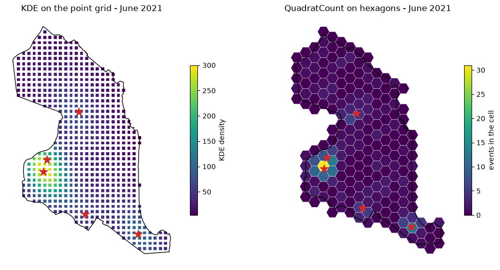

### 3.3 The KDE bandwidth

`bandwidth="silverman"` estimates the kernel width from the spread of the events in the first period and keeps it fixed, which makes densities comparable over time but tends to over-smooth a whole city. A numeric `bandwidth` is used directly as the KDE factor (a multiple of the city-wide spread of the events): smaller values give sharper maps. Compare three settings for the same month — this is the trade-off discussed in the thesis (Chapter 2, Figure 3).

```python
fig, axes = plt.subplots(1, 3, figsize=(16, 5.5))
for ax, bw in zip(axes, ["silverman", 0.2, 0.08]):
    m = KDE(tfreq="M", grid=points, bandwidth=bw)
    st = m.fit_transform(dataset.crimes)
    g = points.copy()
    g["density"] = st.xs(month, level="t").reindex(points.index).values
    g.plot(ax=ax, column="density", cmap="viridis", markersize=10, marker="s")
    city.boundary.plot(ax=ax, color="black", linewidth=1)
    hotspots.plot(ax=ax, color="#d62728", marker="*", markersize=120, zorder=5)
    ax.set_title(f"bandwidth={bw!r} (factor {m.factor:.3f})")
    ax.set_axis_off()
```

fig, axes = plt.subplots(1, 3, figsize=(16, 5.5)) for ax, bw in zip(axes, ["silverman", 0.2, 0.08]): m = KDE(tfreq="M", grid=points, bandwidth=bw) st = m.fit_transform(dataset.crimes) g = points.copy() g["density"] = st.xs(month, level="t").reindex(points.index).values g.plot(ax=ax, column="density", cmap="viridis", markersize=10, marker="s") city.boundary.plot(ax=ax, color="black", linewidth=1) hotspots.plot(ax=ax, color="#d62728", marker="*", markersize=120, zorder=5) ax.set_title(f"bandwidth={bw!r} (factor {m.factor:.3f})") ax.set_axis_off()

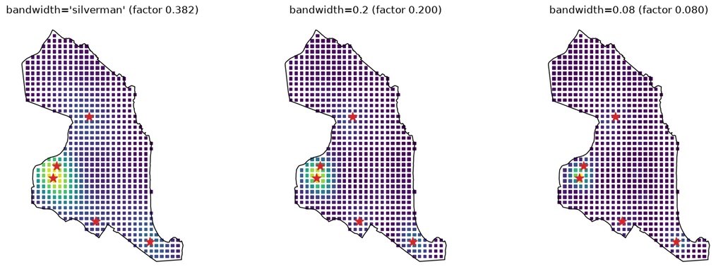

## 4. Time series features

From here on we use `bandwidth=0.2`, a middle ground between the over-smoothed Silverman estimate and a noisy small kernel.

Each place has a monthly series. The feature classes transform it (STL trend, STL seasonal component, first difference or the raw series) and build `lags` lagged columns. `PandasFeatureUnion` aligns them on the `(t, places)` index and drops the warm-up rows. Note the extra row for the month **after** the last observed one — that is the row the model will forecast.

```python
BANDWIDTH = 0.2
stseries = KDE(tfreq="M", grid=points, bandwidth=BANDWIDTH).fit_transform(dataset.crimes)

LAGS = 6
fextraction = PandasFeatureUnion([
    ("ar", AR(lags=3)),
    ("seasonal", Seasonality(lags=LAGS)),
    ("trend", Trend(lags=LAGS)),
    ("diff", Diff(lags=LAGS)),
])
X = fextraction.fit_transform(stseries)
print(X.shape, "| periods:", X.index.get_level_values("t").min().date(), "->", X.index.get_level_values("t").max().date())
X.head(8)
```

BANDWIDTH = 0.2 stseries = KDE(tfreq="M", grid=points, bandwidth=BANDWIDTH).fit_transform(dataset.crimes) LAGS = 6 fextraction = PandasFeatureUnion([ ("ar", AR(lags=3)), ("seasonal", Seasonality(lags=LAGS)), ("trend", Trend(lags=LAGS)), ("diff", Diff(lags=LAGS)), ]) X = fextraction.fit_transform(stseries) print(X.shape, "| periods:", X.index.get_level_values("t").min().date(), "->", X.index.get_level_values("t").max().date()) X.head(8)

```
(19140, 21) | periods: 2019-08-31 -> 2022-01-31
```

| t | places | ar_1 | ar_2 | ar_3 | seasonal_1 | seasonal_2 | seasonal_3 | seasonal_4 | seasonal_5 | seasonal_6 | trend_1 | ... | trend_3 | trend_4 | trend_5 | trend_6 | diff_1 | diff_2 | diff_3 | diff_4 | diff_5 | diff_6 |
| --- | --- | --- | --- | --- | --- | --- | --- | --- | --- | --- | --- | --- | --- | --- | --- | --- | --- | --- | --- | --- | --- | --- |
| 2019-08-31 | 55 | 125.066978 | 33.379474 | 75.417634 | 17.792389 | -30.120816 | -9.378083 | -12.053399 | 28.559599 | 8.725865 | 90.150882 | ... | 85.306595 | 82.496749 | 79.764318 | 77.129447 | 91.687504 | -42.038160 | 5.464522 | -54.822791 | 39.967023 | -6.694205 |
|  | 56 | 119.722317 | 43.676995 | 62.169137 | 15.704561 | -23.082344 | -16.896765 | -5.064126 | 32.536963 | 0.034839 | 91.472046 | ... | 82.901002 | 78.376722 | 73.961567 | 69.744306 | 76.045322 | -18.492142 | -1.109927 | -55.373884 | 41.442033 | -10.483457 |
|  | 57 | 74.955493 | 48.107382 | 44.961841 | 1.650338 | -7.189462 | -9.907225 | -3.787340 | 30.708964 | -8.703507 | 69.222787 | ... | 63.221369 | 60.187650 | 57.331271 | 54.778577 | 26.848111 | 3.145541 | 6.223854 | -59.937445 | 39.288169 | 0.550026 |
|  | 58 | 32.885539 | 37.511566 | 27.005920 | -8.958600 | 0.552562 | -2.519541 | -4.530974 | 23.950183 | -4.966147 | 41.233126 | ... | 39.449199 | 38.574753 | 37.873135 | 37.460754 | -4.626026 | 10.505646 | 11.468861 | -58.689203 | 30.512404 | 15.810417 |
|  | 59 | 10.548101 | 19.797947 | 14.288868 | -10.264510 | -0.437829 | -0.643550 | -2.422139 | 13.554383 | 4.466334 | 21.870406 | ... | 22.048987 | 22.169159 | 22.412970 | 22.869190 | -9.249846 | 5.509079 | 10.369965 | -44.347235 | 15.689751 | 20.004471 |
|  | 60 | 2.208611 | 7.265361 | 10.962395 | -8.091273 | -2.416711 | -0.094430 | -1.558245 | 3.652393 | 12.938206 | 13.415543 | ... | 13.889126 | 14.205965 | 14.612110 | 15.169423 | -5.056750 | -3.697034 | 10.377684 | -26.775176 | -1.408718 | 19.260890 |
|  | 85 | 151.142469 | 43.625061 | 127.863353 | 19.490251 | -48.072805 | 13.097882 | -20.990928 | 31.129092 | 5.988812 | 114.699806 | ... | 112.197090 | 110.646175 | 109.190448 | 107.828026 | 107.517409 | -84.238292 | 43.927759 | -83.758478 | 65.082126 | -23.790069 |
|  | 86 | 197.682505 | 71.207880 | 119.173254 | 30.181598 | -48.819994 | -14.219399 | -10.504940 | 38.803089 | 5.791861 | 147.416078 | ... | 135.466737 | 129.137953 | 122.845369 | 116.675448 | 126.474625 | -47.965375 | 14.792964 | -81.530166 | 67.676212 | -37.023901 |

8 rows × 21 columns

```python
# What the decomposition looks like for the busiest place
busiest = stseries.groupby("places").mean().idxmax()
ts = stseries.xs(busiest, level="places")
from statsmodels.tsa.seasonal import STL
res = STL(ts, period=LAGS).fit()
fig, axes = plt.subplots(4, 1, figsize=(10, 7), sharex=True)
ts.plot(ax=axes[0], title=f"place {busiest}: KDE density per month")
res.trend.plot(ax=axes[1], title="STL trend")
res.seasonal.plot(ax=axes[2], title=f"STL seasonal (period={LAGS})")
ts.diff().plot(ax=axes[3], title="first difference")
for ax in axes:
    ax.set_xlabel("")
fig.tight_layout()
```

# What the decomposition looks like for the busiest place busiest = stseries.groupby("places").mean().idxmax() ts = stseries.xs(busiest, level="places") from statsmodels.tsa.seasonal import STL res = STL(ts, period=LAGS).fit() fig, axes = plt.subplots(4, 1, figsize=(10, 7), sharex=True) ts.plot(ax=axes[0], title=f"place {busiest}: KDE density per month") res.trend.plot(ax=axes[1], title="STL trend") res.seasonal.plot(ax=axes[2], title=f"STL seasonal (period={LAGS})") ts.diff().plot(ax=axes[3], title="first difference") for ax in axes: ax.set_xlabel("") fig.tight_layout()

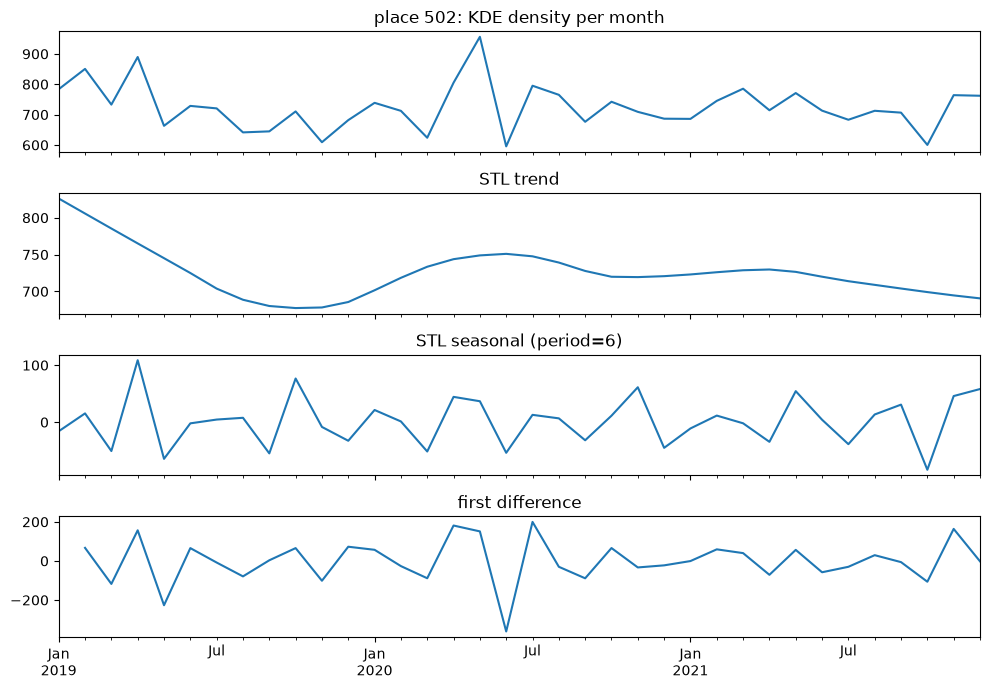

## 5. Fit and evaluate a prediction pipeline

The pipeline chains the mapping, the feature extraction and a scikit-learn estimator. Here the estimator is itself a `Pipeline`: quantile scaling, recursive feature elimination and a random forest, each wrapped so that DataFrames (and the `(t, places)` index) survive every step.

```python
from sklearn.ensemble import RandomForestRegressor
from sklearn.feature_selection import RFE
from sklearn.pipeline import Pipeline
from sklearn.preprocessing import QuantileTransformer

from predspot.feature_engineering import FeatureScaling
from predspot.ml_modelling import FeatureSelection, Model

pipeline = PredictionPipeline(
    mapping=KDE(tfreq="M", grid=points, bandwidth=BANDWIDTH),
    fextraction=PandasFeatureUnion([
        ("ar", AR(lags=3)),
        ("seasonal", Seasonality(lags=LAGS)),
        ("trend", Trend(lags=LAGS)),
        ("diff", Diff(lags=LAGS)),
    ]),
    estimator=Pipeline([
        ("scaling", FeatureScaling(QuantileTransformer(n_quantiles=20, output_distribution="uniform"))),
        ("selection", FeatureSelection(RFE(RandomForestRegressor(n_estimators=20, random_state=0, n_jobs=-1),
                                           n_features_to_select=12, step=3))),
        ("model", Model(RandomForestRegressor(n_estimators=100, min_samples_leaf=2, random_state=0, n_jobs=-1))),
    ]),
    random_state=0,
)
pipeline.fit(dataset)
print("training rows:", pipeline.features.loc[: stseries.index.get_level_values("t").max()].shape[0])
print("next period to forecast:", pipeline.next_time.date())
```

from sklearn.ensemble import RandomForestRegressor from sklearn.feature_selection import RFE from sklearn.pipeline import Pipeline from sklearn.preprocessing import QuantileTransformer from predspot.feature_engineering import FeatureScaling from predspot.ml_modelling import FeatureSelection, Model pipeline = PredictionPipeline( mapping=KDE(tfreq="M", grid=points, bandwidth=BANDWIDTH), fextraction=PandasFeatureUnion([ ("ar", AR(lags=3)), ("seasonal", Seasonality(lags=LAGS)), ("trend", Trend(lags=LAGS)), ("diff", Diff(lags=LAGS)), ]), estimator=Pipeline([ ("scaling", FeatureScaling(QuantileTransformer(n_quantiles=20, output_distribution="uniform"))), ("selection", FeatureSelection(RFE(RandomForestRegressor(n_estimators=20, random_state=0, n_jobs=-1), n_features_to_select=12, step=3))), ("model", Model(RandomForestRegressor(n_estimators=100, min_samples_leaf=2, random_state=0, n_jobs=-1))), ]), random_state=0, ) pipeline.fit(dataset) print("training rows:", pipeline.features.loc[: stseries.index.get_level_values("t").max()].shape[0]) print("next period to forecast:", pipeline.next_time.date())

```
training rows: 18502
next period to forecast: 2022-01-31
```

```python
scores = pipeline.evaluate(["r2", "mse"], cv=3)   # time series CV: train on earlier folds, test on the next
scores.loc["mean"] = scores.mean()
scores
```

scores = pipeline.evaluate(["r2", "mse"], cv=3) # time series CV: train on earlier folds, test on the next scores.loc["mean"] = scores.mean() scores

|  | r2 | mse |
| --- | --- | --- |
| fold 1 | 0.968710 | 364.186782 |
| fold 2 | 0.983170 | 177.396760 |
| fold 3 | 0.985974 | 142.169684 |
| mean | 0.979284 | 227.917742 |

```python
fi = pipeline.feature_importances
ax = fi.sort_values("importance").plot.barh(figsize=(7, 5), legend=False, color="#1f4e79")
ax.set_title("Selected features and their importance")
fi.head(12)
```

fi = pipeline.feature_importances ax = fi.sort_values("importance").plot.barh(figsize=(7, 5), legend=False, color="#1f4e79") ax.set_title("Selected features and their importance") fi.head(12)

|  | importance |
| --- | --- |
| trend_1 | 0.802854 |
| trend_2 | 0.112126 |
| trend_3 | 0.033980 |
| trend_4 | 0.016472 |
| trend_6 | 0.015978 |
| seasonal_6 | 0.007559 |
| diff_6 | 0.002337 |
| ar_2 | 0.002062 |
| diff_5 | 0.002022 |
| ar_1 | 0.001691 |
| seasonal_2 | 0.001469 |
| seasonal_4 | 0.001451 |

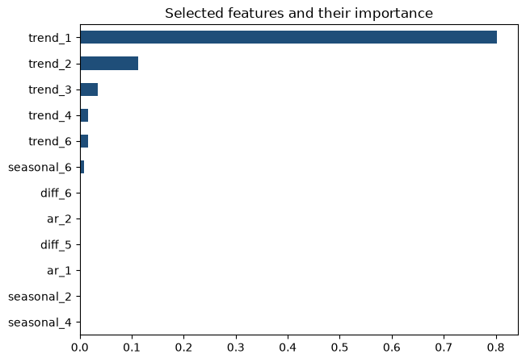

## 6. Forecast the next months

`predict()` returns the density of every place for the period after the last observed one. Each call appends its forecast to the series, recomputes the features and moves the horizon one period forward, so calling it three times gives a three-month recursive forecast.

```python
forecasts = pd.concat([pipeline.predict() for _ in range(3)])
forecasts.groupby("t").describe().round(2)
```

forecasts = pd.concat([pipeline.predict() for _ in range(3)]) forecasts.groupby("t").describe().round(2)

| t | crime_density count | crime_density mean | crime_density std | crime_density min | crime_density 25% | crime_density 50% | crime_density 75% | crime_density max |
| --- | --- | --- | --- | --- | --- | --- | --- | --- |
| 2022-01-31 | 638.0 | 67.37 | 96.78 | 3.64 | 24.29 | 37.09 | 62.40 | 638.06 |
| 2022-02-28 | 638.0 | 66.49 | 104.55 | 2.82 | 17.54 | 34.48 | 61.69 | 711.16 |
| 2022-03-31 | 638.0 | 65.65 | 106.42 | 2.80 | 16.75 | 32.32 | 58.58 | 715.27 |

```python
first_month = forecasts.index.get_level_values("t").min()
fc = points.join(forecasts.xs(first_month, level="t"))
top10 = fc.nlargest(10, "crime_density")[["lon", "lat", "crime_density"]].round(4)
print(f"Top-10 places for {first_month:%B %Y}:")
top10
```

first_month = forecasts.index.get_level_values("t").min() fc = points.join(forecasts.xs(first_month, level="t")) top10 = fc.nlargest(10, "crime_density")[["lon", "lat", "crime_density"]].round(4) print(f"Top-10 places for {first_month:%B %Y}:") top10

```
Top-10 places for January 2022:
```

| places | lon | lat | crime_density |
| --- | --- | --- | --- |
| 502 | -35.2636 | -5.8267 | 638.0591 |
| 533 | -35.2636 | -5.8221 | 629.9240 |
| 501 | -35.2682 | -5.8267 | 611.3991 |
| 471 | -35.2636 | -5.8313 | 608.1633 |
| 503 | -35.2590 | -5.8267 | 602.1349 |
| 534 | -35.2590 | -5.8221 | 580.6709 |
| 532 | -35.2682 | -5.8221 | 571.8658 |
| 470 | -35.2682 | -5.8313 | 539.2236 |
| 472 | -35.2590 | -5.8313 | 522.6021 |
| 564 | -35.2636 | -5.8175 | 506.5837 |

```python
fig, ax = plt.subplots(figsize=(7, 8))
fc.plot(ax=ax, column="crime_density", cmap="magma", markersize=14, marker="s", legend=True,
        legend_kwds={"shrink": 0.6, "label": "forecast density"})
city.boundary.plot(ax=ax, color="black", linewidth=1)
hotspots.plot(ax=ax, color="#00e5ff", marker="*", markersize=170, zorder=5, label="true hotspot centres")
top = fc.nlargest(20, "crime_density")
ax.scatter(top["lon"], top["lat"], s=110, facecolors="none", edgecolors="#00e5ff", linewidths=1.6, label="top-20 forecast")
ax.legend(loc="lower left")
ax.set_title(f"Forecast hotspots for {first_month:%B %Y}")
ax.set_axis_off()
```

fig, ax = plt.subplots(figsize=(7, 8)) fc.plot(ax=ax, column="crime_density", cmap="magma", markersize=14, marker="s", legend=True, legend_kwds={"shrink": 0.6, "label": "forecast density"}) city.boundary.plot(ax=ax, color="black", linewidth=1) hotspots.plot(ax=ax, color="#00e5ff", marker="*", markersize=170, zorder=5, label="true hotspot centres") top = fc.nlargest(20, "crime_density") ax.scatter(top["lon"], top["lat"], s=110, facecolors="none", edgecolors="#00e5ff", linewidths=1.6, label="top-20 forecast") ax.legend(loc="lower left") ax.set_title(f"Forecast hotspots for {first_month:%B %Y}") ax.set_axis_off()

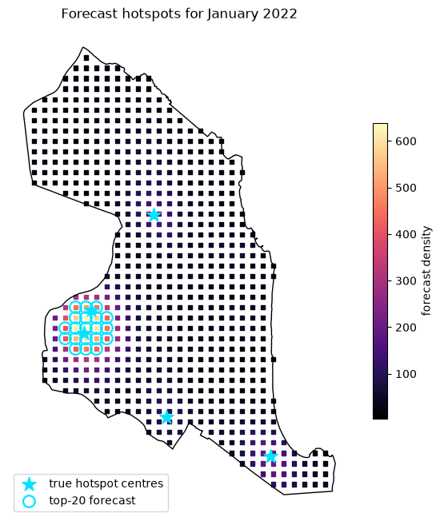

### 6.1 Does the forecast find the true hotspots?

Since the data are synthetic we know where the hotspots are. For each true hotspot centre we look up the nearest grid point and check how it ranks in the forecast (1 = hottest place of the city). Hotspots holding a larger share of the events should rank near the top; small hotspots on a 500 m grid compete with the many grid points that surround the biggest one.

```python
def distance_km(lon1, lat1, lon2, lat2):
    dx = (lon1 - lon2) * 111.32 * np.cos(np.radians((lat1 + lat2) / 2))
    dy = (lat1 - lat2) * 110.57
    return np.hypot(dx, dy)

ranked = fc.sort_values("crime_density", ascending=False)
ranked["rank"] = np.arange(1, len(ranked) + 1)
rows = []
for i, h in hotspots.iterrows():
    d = distance_km(ranked["lon"].values, ranked["lat"].values, h.geometry.x, h.geometry.y)
    nearest = ranked.iloc[int(d.argmin())]
    rows.append({
        "hotspot": i,
        "share_of_events": round(h["share"], 3),
        "nearest_place": int(nearest.name),
        "distance_km": round(float(d.min()), 2),
        "forecast_rank": int(nearest["rank"]),
        "percentile": round(100 * (1 - nearest["rank"] / len(ranked)), 1),
    })
pd.DataFrame(rows).set_index("hotspot").sort_values("forecast_rank")
```

def distance_km(lon1, lat1, lon2, lat2): dx = (lon1 - lon2) * 111.32 * np.cos(np.radians((lat1 + lat2) / 2)) dy = (lat1 - lat2) * 110.57 return np.hypot(dx, dy) ranked = fc.sort_values("crime_density", ascending=False) ranked["rank"] = np.arange(1, len(ranked) + 1) rows = [] for i, h in hotspots.iterrows(): d = distance_km(ranked["lon"].values, ranked["lat"].values, h.geometry.x, h.geometry.y) nearest = ranked.iloc[int(d.argmin())] rows.append({ "hotspot": i, "share_of_events": round(h["share"], 3), "nearest_place": int(nearest.name), "distance_km": round(float(d.min()), 2), "forecast_rank": int(nearest["rank"]), "percentile": round(100 * (1 - nearest["rank"] / len(ranked)), 1), }) pd.DataFrame(rows).set_index("hotspot").sort_values("forecast_rank")

| hotspot | share_of_events | nearest_place | distance_km | forecast_rank | percentile |
| --- | --- | --- | --- | --- | --- |
| 0 | 0.312 | 502 | 0.26 | 1 | 99.8 |
| 3 | 0.114 | 564 | 0.28 | 10 | 98.4 |
| 1 | 0.094 | 148 | 0.19 | 44 | 93.1 |
| 4 | 0.078 | 849 | 0.26 | 58 | 90.9 |
| 2 | 0.051 | 231 | 0.27 | 96 | 85.0 |

```python
# The full history + forecast of the top forecast place
place = fc["crime_density"].idxmax()
series = pipeline.stseries.xs(place, level="places")
observed = series.loc[: stseries.index.get_level_values("t").max()]
predicted = series.loc[forecasts.index.get_level_values("t").min():]
ax = observed.plot(figsize=(10, 3.5), marker="o", label="observed (KDE)")
predicted.plot(ax=ax, marker="*", markersize=12, linestyle="--", color="#d62728", label="forecast")
ax.set_title(f"Place {place}: monthly density and 3-month recursive forecast")
ax.set_xlabel("")
ax.legend()
```

# The full history + forecast of the top forecast place place = fc["crime_density"].idxmax() series = pipeline.stseries.xs(place, level="places") observed = series.loc[: stseries.index.get_level_values("t").max()] predicted = series.loc[forecasts.index.get_level_values("t").min():] ax = observed.plot(figsize=(10, 3.5), marker="o", label="observed (KDE)") predicted.plot(ax=ax, marker="*", markersize=12, linestyle="--", color="#d62728", label="forecast") ax.set_title(f"Place {place}: monthly density and 3-month recursive forecast") ax.set_xlabel("") ax.legend()

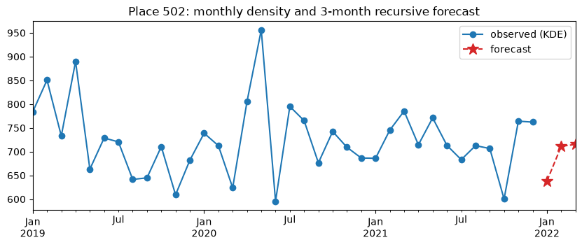

## 7. The same pipeline with counts on hexagons

`QuadratCount` is a drop-in replacement for `KDE`: swap the mapping and the grid, keep everything else.

```python
hex_pipeline = PredictionPipeline(
    mapping=QuadratCount(tfreq="M", grid=hexes),
    fextraction=PandasFeatureUnion([
        ("ar", AR(lags=3)),
        ("seasonal", Seasonality(lags=LAGS)),
        ("trend", Trend(lags=LAGS)),
    ]),
    estimator=RandomForestRegressor(n_estimators=100, min_samples_leaf=2, random_state=0, n_jobs=-1),
    random_state=0,
).fit(dataset)
print("r2 per fold:", np.round(hex_pipeline.evaluate("r2", cv=3), 3))
hex_fc = hexes.join(hex_pipeline.predict().droplevel("t"))

fig, ax = plt.subplots(figsize=(7, 8))
hex_fc.plot(ax=ax, column="crime_density", cmap="magma", edgecolor="white", linewidth=0.3, legend=True,
            legend_kwds={"shrink": 0.6, "label": "forecast events"})
city.boundary.plot(ax=ax, color="black", linewidth=1)
hotspots.plot(ax=ax, color="#00e5ff", marker="*", markersize=170, zorder=5)
ax.set_title(f"Forecast events per hexagon for {hex_pipeline.stseries.index.get_level_values('t').max():%B %Y}")
ax.set_axis_off()
```

hex_pipeline = PredictionPipeline( mapping=QuadratCount(tfreq="M", grid=hexes), fextraction=PandasFeatureUnion([ ("ar", AR(lags=3)), ("seasonal", Seasonality(lags=LAGS)), ("trend", Trend(lags=LAGS)), ]), estimator=RandomForestRegressor(n_estimators=100, min_samples_leaf=2, random_state=0, n_jobs=-1), random_state=0, ).fit(dataset) print("r2 per fold:", np.round(hex_pipeline.evaluate("r2", cv=3), 3)) hex_fc = hexes.join(hex_pipeline.predict().droplevel("t")) fig, ax = plt.subplots(figsize=(7, 8)) hex_fc.plot(ax=ax, column="crime_density", cmap="magma", edgecolor="white", linewidth=0.3, legend=True, legend_kwds={"shrink": 0.6, "label": "forecast events"}) city.boundary.plot(ax=ax, color="black", linewidth=1) hotspots.plot(ax=ax, color="#00e5ff", marker="*", markersize=170, zorder=5) ax.set_title(f"Forecast events per hexagon for {hex_pipeline.stseries.index.get_level_values('t').max():%B %Y}") ax.set_axis_off()

```
r2 per fold: [0.868 0.916 0.929]
```

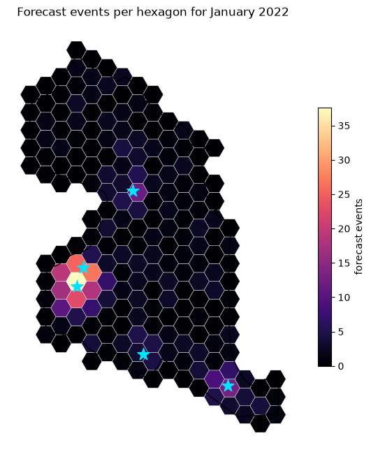

## Wrapping up

To run this on real data, replace the synthetic `crimes` DataFrame with your own `tag, t, lon, lat` table and model each crime type (`tag`) separately, as the framework recommends. See the [documentation](https://adaj.github.io/predspot/) for the details of every step.